# A2 - Analise de Dados Meteorologicos

## Alunos:

- Paulo José Marques ([Github](https://github.com/PauloJMarques), [Linkedln](https://www.linkedin.com/in/paulojosemarques/));
- Felipe Stelet ([Linkedln](https://www.linkedin.com/in/felipe-stelet-bb5ab5213/)).

# Objetivos do Trabalho:

- Relacionar as informações do Instituto Nacional de Meteorologia e buscar uma análise das chuvas nos últimos anos.
- Site da base de dados: https://portal.inmet.gov.br

# Próximos passos para a A2:

- Análise dos dados, utilizar alguma medida estatística para prever possíveis chuvas de grande porte;
- Acessar a API do INMET para possibilitar o download de todos os estados e períodos possíveis da base de dados, é importante comentar que sem essa API para coletar os dados de forma automatica não é possível fazer os gráficos das regiões do país;
- Utilizar a biblioteca do google para plotar gráficos de mapa para representar os níveis de chuva das regiões do país.

# Pacotes Utilizados:

- Plotar graficos;
- Acessar dados do excel;
- No futuro pacote para leitura de dados na API.

```r
library(readxl)
library(tidyverse)
library(lubridate)
```

# Acessando os Dados:

```r
df = read_excel(path = "df_planilha.xlsx", skip= 8)
```

# Visualizacao dos Dados:

```r
df
```

```
## # A tibble: 2,160 × 19
##    Data       `Hora UTC` `PRECIPITA«√O TOTAL…` `PRESSAO ATMOS…` `PRESS√O ATMOS…`
##    <chr>      <chr>                      <dbl>            <dbl>            <dbl>
##  1 2022-01-01 0000 UTC                     0.6             895.             895.
##  2 2022-01-01 0100 UTC                     0.6             895.             895.
##  3 2022-01-01 0200 UTC                     0.6             895.             895.
##  4 2022-01-01 0300 UTC                     0               894.             895.
##  5 2022-01-01 0400 UTC                     0               894.             894.
##  6 2022-01-01 0500 UTC                     0               893              894.
##  7 2022-01-01 0600 UTC                     0               893.             893
##  8 2022-01-01 0700 UTC                     0               893.             893.
##  9 2022-01-01 0800 UTC                     0               894.             894.
## 10 2022-01-01 0900 UTC                     0               894.             894
## # … with 2,150 more rows, and 14 more variables:
## #   `PRESS√O ATMOSFERICA MIN. NA HORA ANT. (AUT) (mB)` <dbl>,
## #   `RADIACAO GLOBAL (Kj/m≤)` <dbl>,
## #   `TEMPERATURA DO AR - BULBO SECO, HORARIA (∞C)` <dbl>,
## #   `TEMPERATURA DO PONTO DE ORVALHO (∞C)` <dbl>,
## #   `TEMPERATURA M¡XIMA NA HORA ANT. (AUT) (∞C)` <dbl>,
## #   `TEMPERATURA MÕNIMA NA HORA ANT. (AUT) (∞C)` <dbl>, …
```

## Arrumando os Dados:

Dados que buscamos para as análises:

### Dados Diários:

```r
df_dias = df %>%
  group_by(Data) %>%
  summarise(Total_Precipitacao_mm=sum(`PRECIPITA«√O TOTAL, HOR¡RIO (mm)`),Temperatura_Minima_Media_C=mean(`TEMPERATURA M¡XIMA NA HORA ANT. (AUT) (∞C)`), Velocidade_Vento_Media_ms=mean(`VENTO, VELOCIDADE HORARIA (m/s)`))
df_dias
```

```
## # A tibble: 90 × 4
##    Data       Total_Precipitacao_mm Temperatura_Minima_Media_C Velocidade_Vento…
##    <chr>                      <dbl>                      <dbl>             <dbl>
##  1 2022-01-01                  30                         19.8              3.26
##  2 2022-01-02                  19                         20.4              2.22
##  3 2022-01-03                   6.8                       20.5              2.51
##  4 2022-01-04                   1.8                       20.6              2.68
##  5 2022-01-05                   3.6                       20.7              2.66
##  6 2022-01-06                  29.6                       20.7              2.93
##  7 2022-01-07                  59.2                       19.0              2.31
##  8 2022-01-08                  23.6                       18.3              2.89
##  9 2022-01-09                   9.8                       17.6              1.88
## 10 2022-01-10                  26.8                       19.1              1.98
## # … with 80 more rows
```

#### Gráfico:

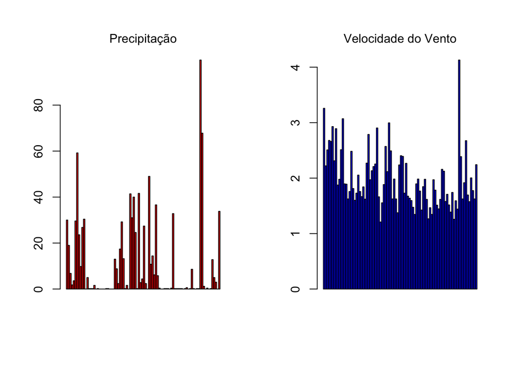

```r
par(mfrow=c(1,2))
barplot(df_dias$Total_Precipitacao_mm, col= 'red')
mtext(text = 'Precipitação', side=3, line=1)
barplot(df_dias$Velocidade_Vento_Media_ms, col = 'blue')
mtext(text = 'Velocidade do Vento', side=3, line=1)
```

### Dados Mensais:

```r
df_mensal = df
df_mensal$Data = paste0(year(df_mensal$Data),'-', month(df_mensal$Data))

df_mensal = df_mensal %>%
  group_by(Data) %>%
  summarise(Total_Precipitacao_mm=sum(`PRECIPITA«√O TOTAL, HOR¡RIO (mm)`),Temperatura_Minima_Media_C=mean(`TEMPERATURA M¡XIMA NA HORA ANT. (AUT) (∞C)`), Velocidade_Vento_Media_ms=mean(`VENTO, VELOCIDADE HORARIA (m/s)`))

df_mensal
```

```
## # A tibble: 3 × 4
##   Data   Total_Precipitacao_mm Temperatura_Minima_Media_C Velocidade_Vento_Medi…
##   <chr>                  <dbl>                      <dbl>                  <dbl>
## 1 2022-1                  273.                       20.9                   2.20
## 2 2022-2                  401                        20.0                   1.92
## 3 2022-3                  268.                       20.2                   1.81
```

#### Gráfico:

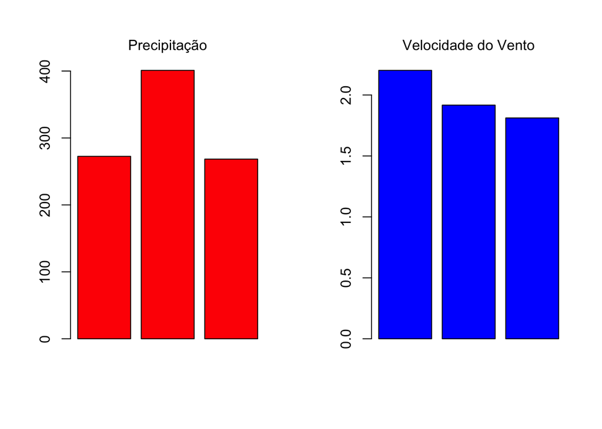

```r
par(mfrow=c(1,2))
barplot(df_mensal$Total_Precipitacao_mm, col= 'red')
mtext(text = 'Precipitação', side=3, line=1)
barplot(df_mensal$Velocidade_Vento_Media_ms, col = 'blue')
mtext(text = 'Velocidade do Vento', side=3, line=1)
```